# Teradata

# Mouth publicity is more effective

```r
temp9<-plyr::count(teamsbike_clean,"Team_Division")
head(temp9[order(-temp9$freq),],n=25)
```

```
##                               Team_Division  freq
## 7                        friends and family 21639
## 6                                 corporate  7686
## 15                                  unknown  3291
## 10 organization (clubs; civic groups; etc.)   255
## 12                                   school   101
## 11                                religious    70
## 8                                    ohana     23
## 4                                 bike shop    16
## 9                                 open team    15
## 14                           small business     9
## 2                              beer/brewery     7
## 5                                civic team     7
## 13                                  school      7
## 3                                 bike club     4
## 1                               association     1
```

# Analysis on Companies

- Finding companies which have most participation on top80p events and btm30p events. Then extracting those companies which are present in both. Those companies have growth opportunity

```r
temp7<-plyr::count(df3,"Company")
lessthan20_top80p <- temp7[temp7$freq < 20,]
temp8<-plyr::count(df4,"Company")
lessthan20_btm30p <- temp8[temp8$freq < 20,]
temp10 <- lessthan20_top80p[lessthan20_top80p$Company %in% lessthan20_btm30p$Company,]
dim(temp10)
```

[output not shown]

- Lets remove somellp since it is not useful

```r
temp10 <- temp10[!(temp10$Company == 'some llp'),]
unique(temp10$Company)
```

```
##  [1] "accenture"                "acme"
##  [3] "buildium llc"             "corner cycle"
##  [5] "cox communications"       "dickie's devils"
##  [7] "exodus pest control"      "fidelity investments"
##  [9] "hard rock international"  "monsanto"
## [11] "nmss"                     "riemer & braunstein llp"
## [13] "sanofi genzyme bike team" "simple again"
## [15] "starbucks"                "strategies"
## [17] "us navy"                  "waterford development"
```

- Now we have companies which has potential to grow, so lets extract their details from original teams dataset

```r
temp11 <-   teamsbike_clean$Company %in% temp10$Company
temp12 <- teamsbike_clean[temp11,]
#colnames(temp12)
```

- Now we want to check if number fof participants in there companies are incereasing or decreasing, so we will aggregate the number of participants w.r.t comapny and fiscal year

```r
temp13 <- aggregate(Number_of_Participants~Company+Fiscal_Year,data=temp12,FUN=length)
temp13 <- temp13[order(temp13$Company),]
head(temp13)
```

```
##      Company Fiscal_Year Number_of_Participants
## 1  accenture        2013                      8
## 12 accenture        2014                      7
## 26 accenture        2015                      5
## 37 accenture        2016                      6
## 54 accenture        2017                      5
## 66 accenture        2018                      1
```

- Now we will plot the no of participants for each fiscal year for our 18 companies

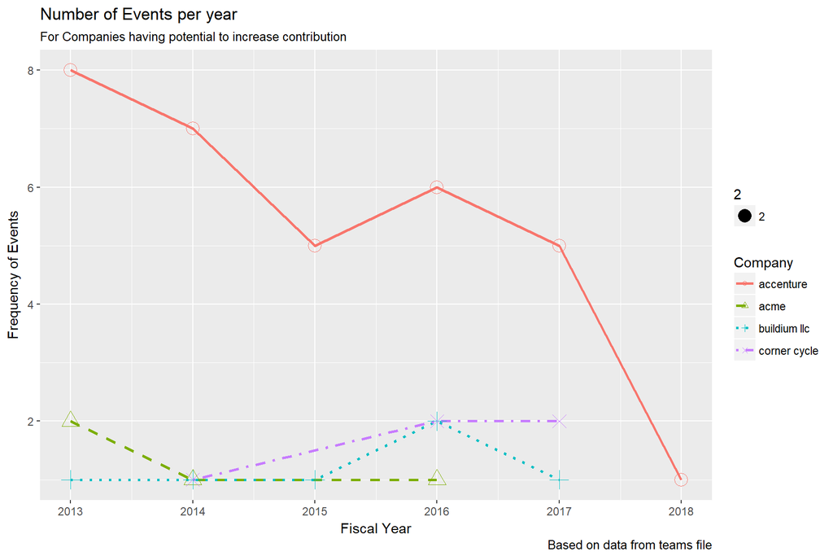

```r
g1 <- (ggplot(
data = temp13[1:17, ],
aes(
x = Fiscal_Year,
y = Number_of_Participants,
group = Company,
colour = Company
)
) +
geom_line(aes(linetype = Company), size = 1) +
geom_point(aes(shape = Company, size = 2)) +
scale_linetype_manual(values = seq(1, 19)) +
scale_shape_manual(values = seq(1, 19)))
g1 + labs(y = "Frequency of Events",x="Fiscal Year",title="Number of Events per year",subtitle="For Companies having potential to increase contribution",caption="Based on data from teams file") +guides(fill=TRUE)
```

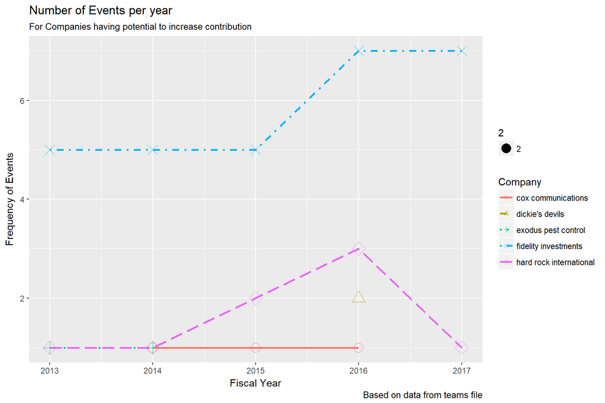

```r
g2 <- (ggplot(
data = temp13[18:33, ],
aes(
x = Fiscal_Year,
y = Number_of_Participants,
group = Company,
colour = Company
)
) +
geom_line(aes(linetype = Company), size = 1) +
geom_point(aes(shape = Company, size = 2)) +
scale_linetype_manual(values = seq(1, 19)) +
scale_shape_manual(values = seq(1, 19)))
g2 + labs(y = "Frequency of Events",x="Fiscal Year",title="Number of Events per year",subtitle="For Companies having potential to increase contribution",caption="Based on data from teams file") +guides(fill=TRUE)
```

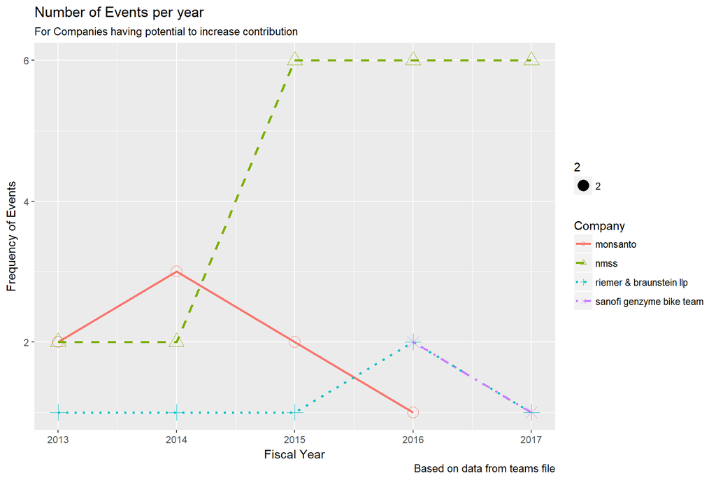

```r
g3 <- (ggplot(
data = temp13[34:49, ],
aes(
x = Fiscal_Year,
y = Number_of_Participants,
group = Company,
colour = Company
)
) +
geom_line(aes(linetype = Company), size = 1) +
geom_point(aes(shape = Company, size = 2)) +
scale_linetype_manual(values = seq(1, 19)) +
scale_shape_manual(values = seq(1, 19)))
g3 + labs(y = "Frequency of Events",x="Fiscal Year",title="Number of Events per year",subtitle="For Companies having potential to increase contribution",caption="Based on data from teams file") +guides(fill=TRUE)
```

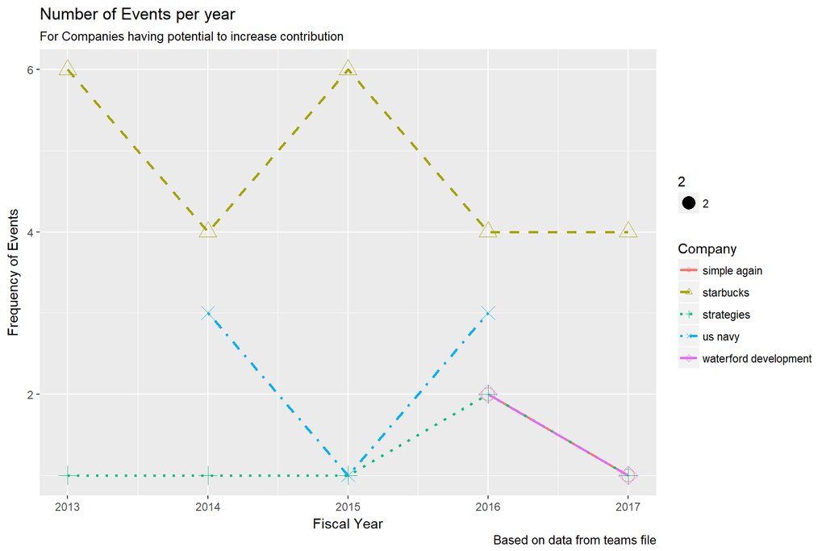

```r
g4 <- (ggplot(
data = temp13[50:66, ],
aes(
x = Fiscal_Year,
y = Number_of_Participants,
group = Company,
colour = Company
)
) +
geom_line(aes(linetype = Company), size = 1) +
geom_point(aes(shape = Company, size = 2)) +
scale_linetype_manual(values = seq(1, 19)) +
scale_shape_manual(values = seq(1, 19)))

g4 + labs(y = "Frequency of Events",x="Fiscal Year",title="Number of Events per year",subtitle="For Companies having potential to increase contribution",caption="Based on data from teams file") +guides(fill=TRUE)
```

# What occupations were responsible for most of our fundraising?

```r
#import teams data
participantbike_clean = read.csv("participantbike_clean.csv")
#summary(participantbike_clean)
participantbike_clean <- subset(participantbike_clean, select = -c(X))
#colnames(participantbike_clean)
#change everything text to lowercase

participantbike_clean[, c(1, 3, 5, 6, 8, 11, 13, 14, 15, 16, 17, 23, 24, 25, 26, 27, 28,29,31,33,36,37,38,39)] <- sapply(participantbike_clean[, c(1, 3, 5, 6, 8, 11, 13, 14, 15, 16, 17, 23, 24, 25, 26, 27, 28,29,31,33,36,37,38,39)], tolower)

#head(participantbike_clean)

#top80eventsdf contains best events,extraing those event id, then finding the occupation and performing an aggregation
#will help us answer this question

temp15 <- participantbike_clean$Event_ID %in% top80eventsdf$Event_ID
temp16 <- participantbike_clean[temp15,]
#dim(temp16)

#colnames(temp16)
#extracting only occupations,team_division,total
temp17 <- temp16[,c(18,21,22,25,32,33)]

occupation_count <- plyr::count(temp17,"Participant_Occupation")
occupation_count_df <- as.data.frame(occupation_count)
#Since some occupation could be of different type but belong to same set,use fuzzy matching

df1<-occupation_count$Participant_Occupation
df2<-occupation_count$Participant_Occupation
df1 <- as.data.frame(df1)
df2 <- as.data.frame(df2)
df1$names_from_df2 <- " "
names(df1) <- c("Participant_Occupation","names_from_df2")
#colnames(df1)
names(df2) <- c("Participant_Occupation")
#dim(df1)
#dim(df2)
yournewvector <- lapply(df1$Participant_Occupation,agrep,df2$Participant_Occupation,max.distance=0.2)
#yournewvector

#write.csv(df2, file="df2.csv", row.names=FALSE)

#It is not very useful in our case
```

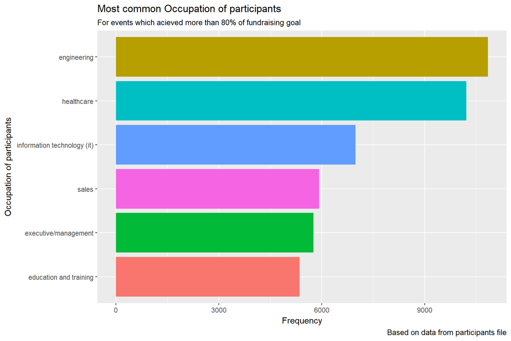

```r
occupation_count <- occupation_count[order(-occupation_count$freq),]
occupation_count_gg <- occupation_count[order(-occupation_count$freq),]
temp19 <- occupation_count_gg[2:7,] #top 5 except unknown
p<- ggplot(data=temp19, aes(x = reorder( Participant_Occupation,freq), y = freq,fill=Participant_Occupation )) + geom_bar(stat ='identity')
p + coord_flip() + labs(y = "Frequency",x="Occupation of participants",title="Most common Occupation of participants",subtitle="For events which acieved more than 80% of fundraising goal",caption="Based on data from participants file") +guides(fill=FALSE)
```

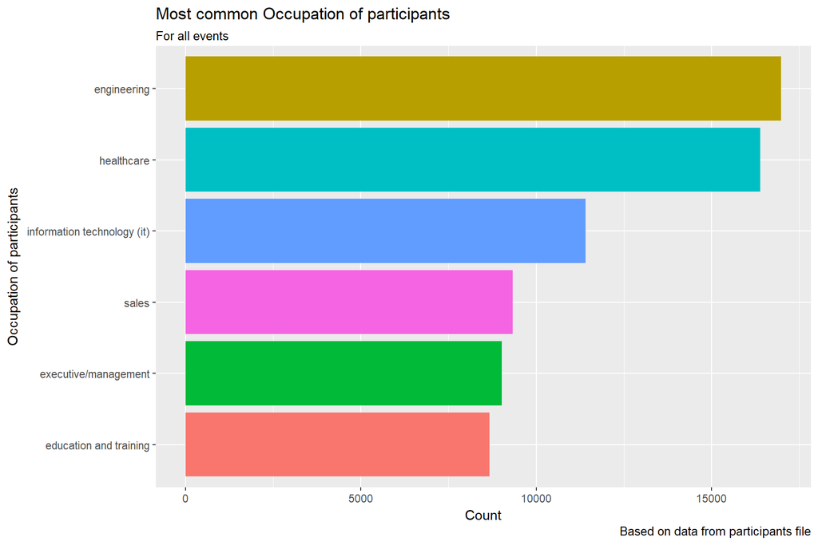

```r
occupation_count_forall <- plyr::count(participantbike_clean,"Participant_Occupation")
occupation_count_forall <- occupation_count_forall[order(-occupation_count_forall$freq),]

p<- ggplot(data=occupation_count_forall[2:7,], aes(x = reorder( Participant_Occupation,freq), y = freq,fill=Participant_Occupation )) + geom_bar(stat ='identity')
p + coord_flip() + labs(y = "Count",x="Occupation of participants",title="Most common Occupation of participants",subtitle="For all events",caption="Based on data from participants file") +guides(fill=FALSE)
```

- Engineering, Healthcare , IT, Sales, Management & Education

# common attributes in top performing corporate teams

```r
df5 <- teamsbike_clean[, c(3, 10, 14)]
#unique(df5$Team_Division)
#dim(df5)
#colnames(df5)
temp20 <- df5[df5$Team_Division == 'corporate', ]

#head(temp20)

temp21 <- temp20[order(-temp20$Team_Total_Confirmed), ]

top50corpteams <- head(temp21, 50)

temp22 <-
participantbike_clean[participantbike_clean$Event_ID %in%  top50corpteams$Event_ID, ]

#head(temp22)
```

- by type

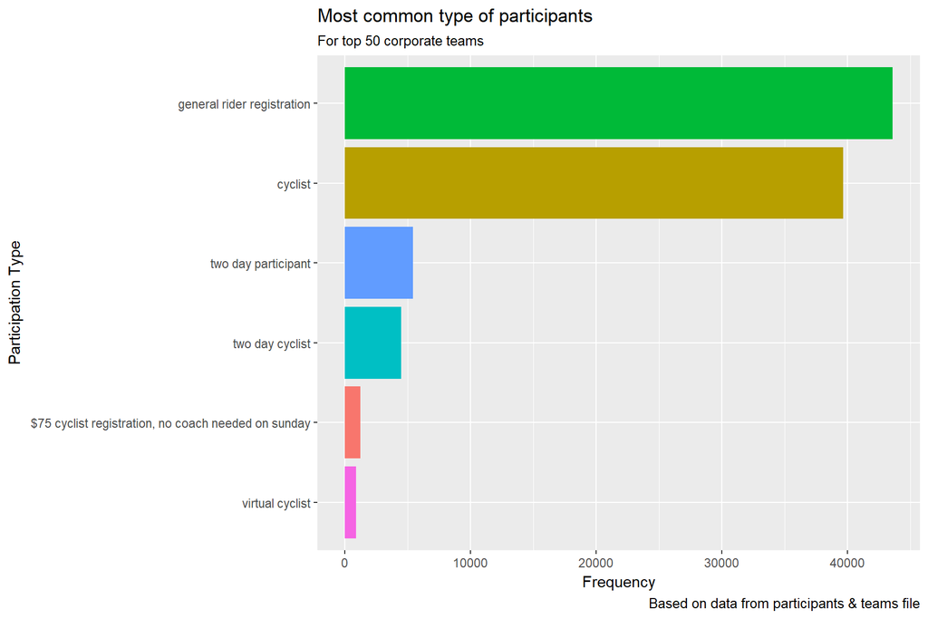

```r
temp23 <- plyr::count(temp22,"Participation_Type_Name")

temp23 <- temp23[order(-temp23$freq),]

#colnames(temp23)

p1<- ggplot(data=head(temp23[order(-temp23$freq),]), aes(x = reorder( Participation_Type_Name,freq), y = freq,fill=Participation_Type_Name )) + geom_bar(stat ='identity')

p1 + coord_flip()+labs(y = "Frequency",x="Participation Type",title="Most common type of participants",subtitle="For top 50 corporate teams",caption="Based on data from participants & teams file") +guides(fill=FALSE)
```

- by occupation

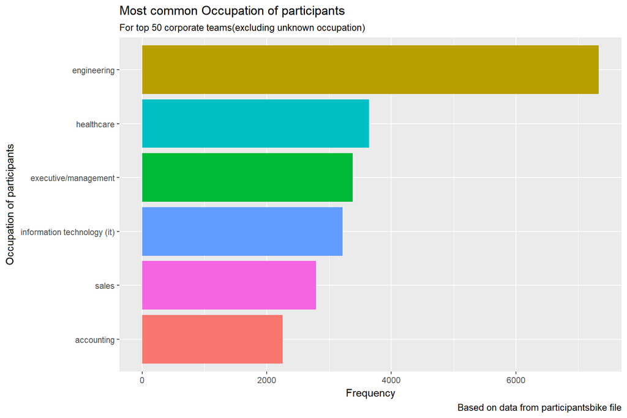

```r
temp24 <- plyr::count(temp22,"Participant_Occupation")
temp24 <- temp24[order(-temp24$freq),]
temp25 <- temp24[!temp24$Participant_Occupation=='unknown',]
p2<- ggplot(data=head(temp25), aes(x = reorder( Participant_Occupation,freq), y = freq,fill=Participant_Occupation )) + geom_bar(stat ='identity')
p2 + coord_flip() + labs(y = "Frequency",x="Occupation of participants",title="Most common Occupation of participants",subtitle="For top 50 corporate teams(excluding unknown occupation)",caption="Based on data from participantsbike file") + guides(fill=FALSE)
```

- by connectiontoms

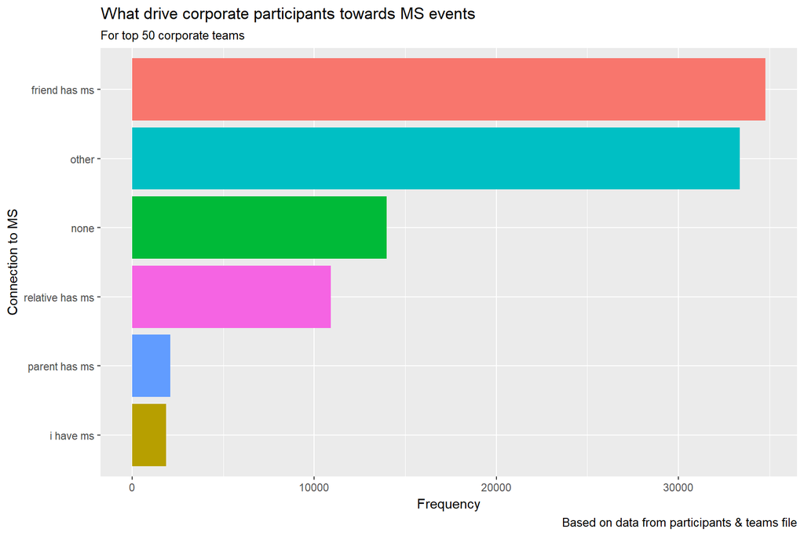

```r
temp26 <- plyr::count(temp22,"Participant_Connection_to_MS")
temp26 <- temp26[order(-temp26$freq),]
p3<- ggplot(data=head(temp26), aes(x = reorder(Participant_Connection_to_MS,freq), y = freq,fill=Participant_Connection_to_MS )) + geom_bar(stat ='identity')
p3 + coord_flip() +labs(y = "Frequency",x="Connection to MS",title="What drive corporate participants towards MS events",subtitle="For top 50 corporate teams",caption="Based on data from participants & teams file") + guides(fill=FALSE)
```

- by State

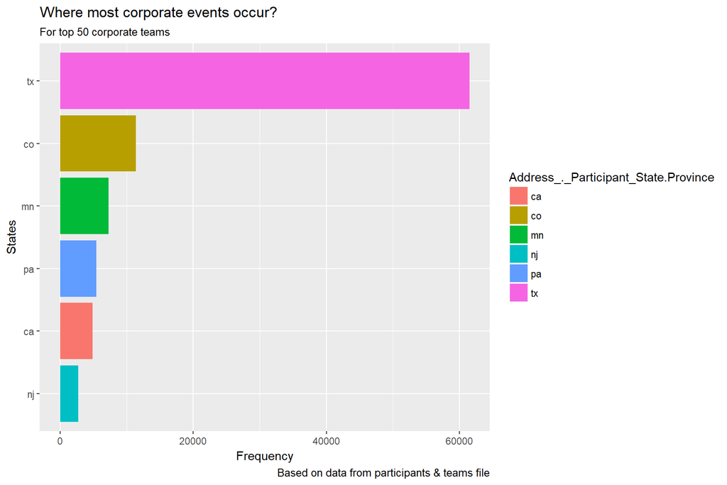

```r
temp27 <- plyr::count(temp22,"Address_._Participant_State.Province")
temp27 <- temp27[order(-temp27$freq),]
p4<- ggplot(data=head(temp27), aes(x = reorder(Address_._Participant_State.Province,freq), y = freq,fill=Address_._Participant_State.Province )) + geom_bar(stat ='identity')
p4 + coord_flip()+labs(y = "Frequency",x="States",title="Where most corporate events occur?",subtitle="For top 50 corporate teams",caption="Based on data from participants & teams file") + guides((fill=FALSE))
```

- by registration type

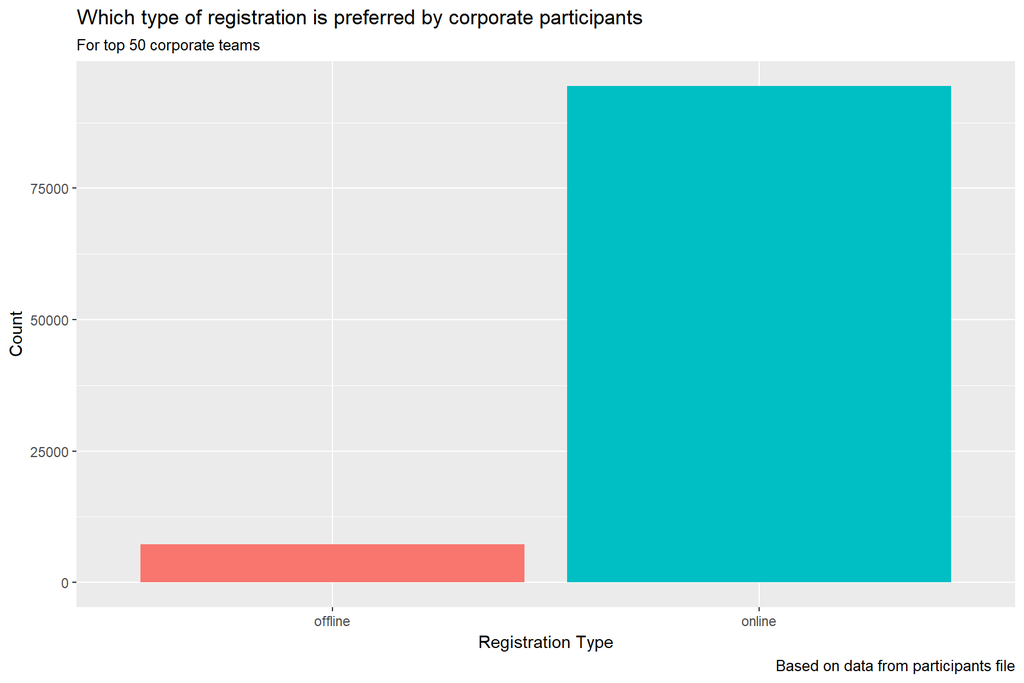

```r
temp28 <- plyr::count(temp22,"Registration_Type")
temp28 <- temp28[order(-temp28$freq),]
#table(temp28)
p5<- ggplot(data=head(temp28), aes(x = reorder(Registration_Type,freq), y = freq,fill=Registration_Type )) + geom_bar(stat ='identity')
p5 + labs(y = "Count",x="Registration Type",title="Which type of registration is preferred by corporate participants",subtitle="For top 50 corporate teams",caption="Based on data from participants file")+guides(fill=FALSE)
```

- by gender

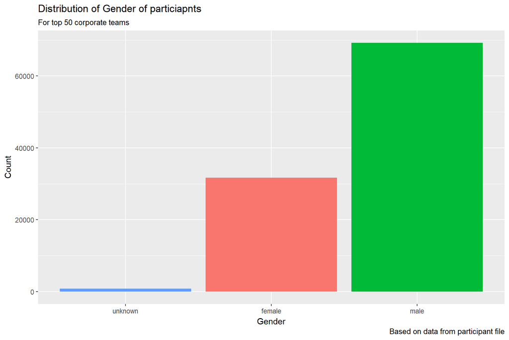

```r
temp29 <- plyr::count(temp22,"Participant_Gender")
temp29 <- temp29[order(-temp29$freq),]
#table(temp29)
p6<- ggplot(data=head(temp29), aes(x = reorder(Participant_Gender,freq), y = freq,fill=Participant_Gender )) + geom_bar(stat ='identity')
p6 + labs(y = "Count",x="Gender",title="Distribution of Gender of particiapnts",subtitle="For top 50 corporate teams",caption="Based on data from participant file")+guides(fill=FALSE)
```

- by industry including unknown occupation

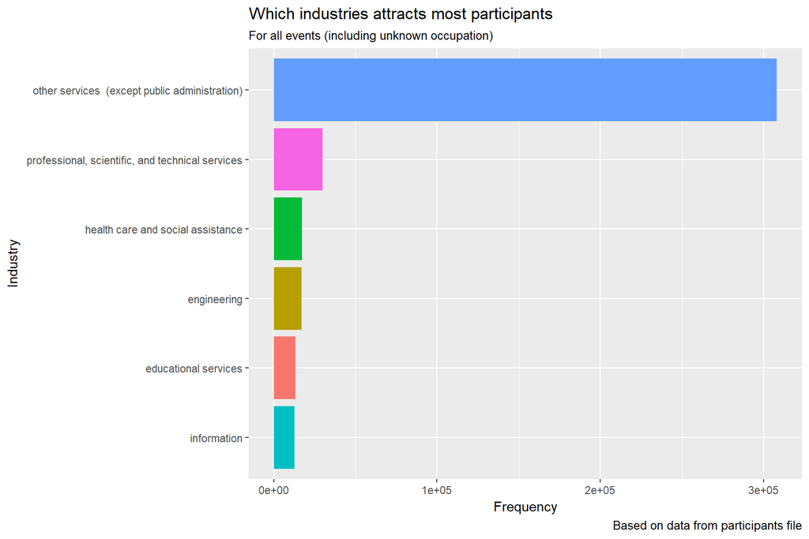

```r
temp32 <- plyr::count(participantbike_clean, "Industry")
temp32 <- temp32[order(-temp32$freq), ]
p8 <- ggplot(data = head(temp32), aes(x = reorder(Industry, freq), y = freq, fill = Industry)) + geom_bar(stat = "identity")
p8 + coord_flip() +labs(y = "Frequency",x="Industry",title="Which industries attracts most participants",subtitle="For all events (including unknown occupation)",caption="Based on data from participants file")+guides(fill=FALSE)
```

- by industry excluding unknown occupation

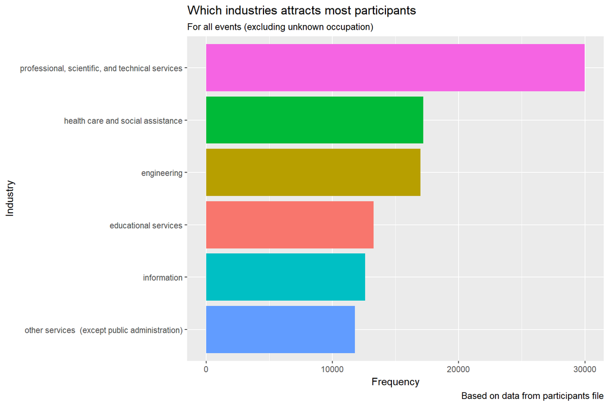

```r
temp33 <-   filter(participantbike_clean,!Participant_Occupation == "unknown")
#dim(temp33)
temp34 <- plyr::count(temp33, "Industry")
temp34 <- temp34[order(-temp34$freq), ]
p9 <- ggplot(data = head(temp34), aes(x = reorder(Industry, freq), y = freq, fill = Industry)) + geom_bar(stat = "identity")
p9 + coord_flip()  +labs(y = "Frequency",x="Industry",title="Which industries attracts most participants",subtitle="For all events (excluding unknown occupation)",caption="Based on data from participants file")+guides(fill=FALSE)
```

- in events data checking average team size for top corporate teams

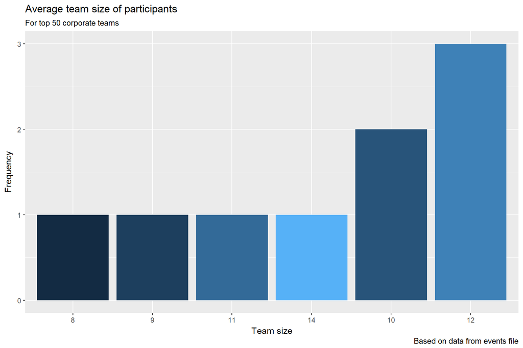

```r
temp30 <- eventsbike_clean[eventsbike_clean$Event_ID %in% top50corpteams$Event_ID,]
#head(temp30)
temp31 <- plyr::count(temp30,"Average_Team_Size")

p7<- ggplot(data=head(temp31), aes(x = reorder(Average_Team_Size,freq), y = freq,fill=Average_Team_Size )) + geom_bar(stat ='identity')
p7  +labs(y = "Frequency",x="Team size",title="Average team size of participants",subtitle="For top 50 corporate teams",caption="Based on data from events file")+guides(fill=FALSE)
```

# Assessing competitive events

- Bestbuddies Boston Hynnais port
- Bestbuddies San Simone - no presence of MS

```r
#colnames(participantbike_clean)
#df for events having in miami
florida <- participantbike_clean[participantbike_clean$Address_._Participant_State.Province=="fl",]
temp100 <- grep("*miami*",florida$Address_._Participant_City)
miami <- florida[temp100,]
#df for events in boston
boston <- participantbike_clean[participantbike_clean$Address_._Participant_City == "boston",]
bestbuddies <- rbind(miami,boston)
mean(bestbuddies$Total_Not_From_Participant)
```

```
## [1] 616.4392
```

```r
mean(bestbuddies$Number_Not_From_Participant)
```

```
## [1] 6.726452
```

```r
#df for st louis
mo <- participantbike_clean[participantbike_clean$Address_._Participant_State.Province=="mo",]
temp101 <- grep("*st. louis*",mo$Address_._Participant_City)
st_louis <- mo[temp101,]
#df for san diego
sandiego <- participantbike_clean[participantbike_clean$Address_._Participant_City == "san diego",]

pedalthecause <- rbind(st_louis,sandiego)

sum(pedalthecause$Total_of_All_Confirmed_Gifts)
```

```
## [1] 1808037
```

MS society vs bestbuddies raised average $616 by participant (which does not include their own contribution)

```r
donations <- read.csv("donations2013_2017.csv")

alldonors <- length(unique(donations$Donor_Member_ID))
alldonors
```

```
## [1] 1929879
```

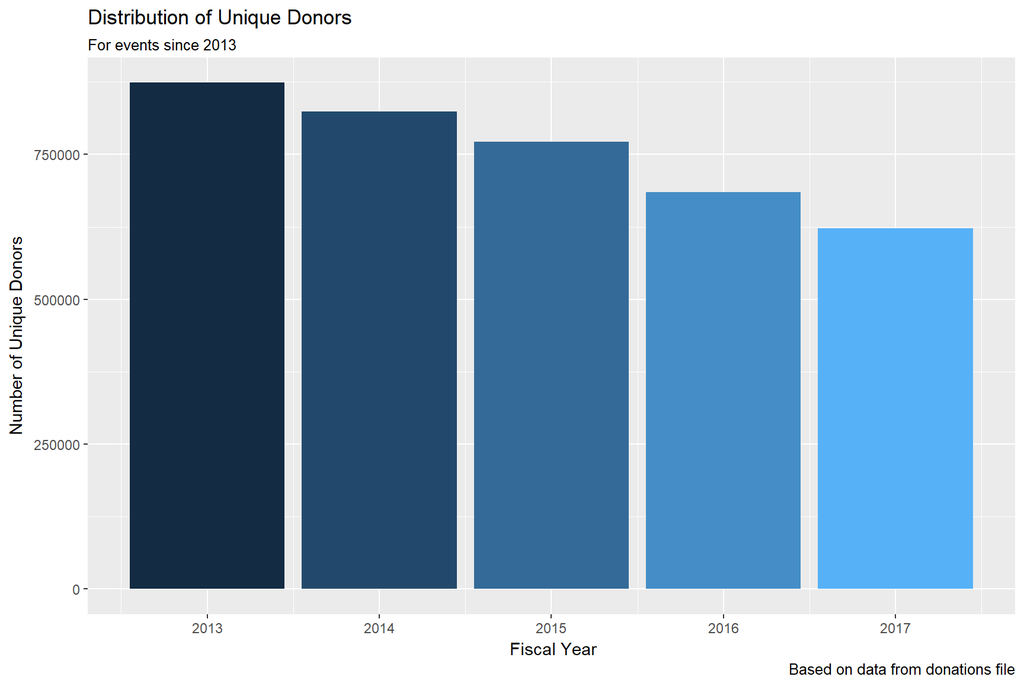

```r
temp500 <- donations[,c('Donor_Member_ID','Fiscal_Year')]
#colnames(temp500)

uniqueindex <- as.numeric(rownames(unique(temp500)[1]))

temp501 <- temp500[uniqueindex,]

#temp502 <- aggregate(Donor_Member_ID~Fiscal_Year,data=temp501,FUN=length)
temp502 <- aggregate(Donor_Member_ID~Fiscal_Year,data=donations,FUN=length)
p9<- ggplot(data=temp502[2:6,], aes(x = Fiscal_Year, y = Donor_Member_ID,fill= Fiscal_Year )) + geom_bar(stat ='identity')
options(scipen=1000000)
p9  +labs(y = "Number of Unique Donors",x=" Fiscal Year",title="Distribution of Unique Donors",subtitle="For events since 2013",caption="Based on data from donations file")+guides(fill=FALSE)
```

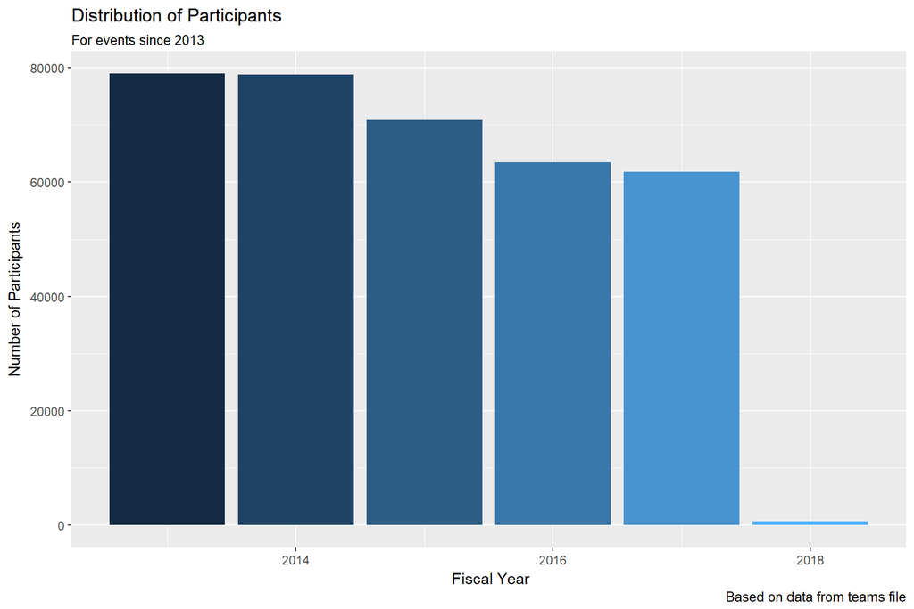

```r
#(teamsbike_clean$Number_of_Participants)

temp503 <- aggregate(Number_of_Participants~Fiscal_Year,data=teamsbike_clean,FUN=sum)
p10<- ggplot(data=temp503, aes(x = Fiscal_Year, y = Number_of_Participants,fill= Fiscal_Year )) + geom_bar(stat ='identity')
options(scipen=1000000)
p10  +labs(y = "Number of Participants",x=" Fiscal Year",title="Distribution of Participants",subtitle="For events since 2013",caption="Based on data from teams file")+guides(fill=FALSE)
```

```r
temp502 <- temp502[2:6,]
temp503 <- temp503[1:5,]
names(temp502) <- c("Fiscal_Year","Number_of_Donors")

Fiscal_Year<- temp502$Fiscal_Year

donor_participant_ratio <- temp502$Number_of_Donors/temp503$Number_of_Participants



temp504 <- data.frame(Fiscal_Year,donor_participant_ratio)

temp504
```

```
##   Fiscal_Year donor_participant_ratio
## 1        2013                11.06629
## 2        2014                10.46375
## 3        2015                10.89239
## 4        2016                10.79209
## 5        2017                10.07157
```

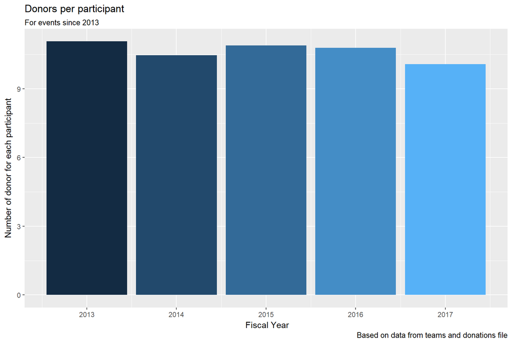

```r
p11<- ggplot(data=temp504, aes(x = Fiscal_Year, y = donor_participant_ratio,fill= Fiscal_Year )) + geom_bar(stat ='identity')
options(scipen=1000000)
p11  +labs(y = "Number of donor for each participant",x=" Fiscal Year",title="Donors per participant",subtitle="For events since 2013",caption="Based on data from teams and donations file")+guides(fill=FALSE)
```

Bestbuddies raised $2553 13 donors

pedalthecause 81000 donars 19809668 total donation

pelotonia 157751378$ raised since 2009 1362303 since in 2018 156389075 2009-2017 $ 19548634 per year

pan mass challenge 2017(http://archive.boston.com/news/local/gallery/080407PanMassChallenge?pg=2)

5000 riders